# STAT 350 Worksheet #1 Solution

Timothy Reese

# Introduction

In this exercise, we will analyze a dataset from a study by Potvin, Lechowicz, and Tardif (1990), which examined how the grass species Echinochloa crus galli responds to environmental changes. Data were collected from twelve plants, six from Quebec, Canada, and six from Mississippi, USA. Half of the plants from each location were subjected to an overnight chilling treatment, while the others were left unchilled. CO2 uptake rates were measured at seven levels of ambient CO2 concentration for each plant, resulting in 84 observations. This dataset provides an opportunity to practice core statistical skills, including working with categorical and numerical data and creating visualizations such as histograms and boxplots.

The data analyzed in this worksheet comes from the study by Potvin et al. (1990):  
Potvin, C., Lechowicz, M. J., and Tardif, S. (1990). “The statistical analysis of ecophysiological response curves obtained from experiments involving repeated measures.” *Ecology*, 71, 1389–1400.

The CO2 dataset is included in the base R installation, making it readily accessible for analysis. To load and explore this dataset, run the following R command: data(package = “datasets”, “CO2”). After running the command, a data variable named CO2 should appear in your environment (visible in the top-right pane) as a promise. A promise is a part of R’s lazy loading process to delay the evaluation of something until it is needed.

The help command provides comprehensive documentation for R’s functionality, including datasets, functions, and packages. This includes detailed explanations of variables, their meanings, measurement units (if applicable), and often usage examples. To learn more about the dataset and its structure and properties, use the help command as follows: help(CO2).

## Question 1: Variables and Measurement Units

Using the information from the help documentation (visible in the bottom-right pane), list all the variables in the dataset and specify the measurement units where applicable (e.g., feet, miles, etc.).

Using the `help(CO2)` command, list all the variables in the dataset and specify their measurement units where applicable.

```r
# Load CO2 dataset and view help documentation
data("CO2")
help(CO2)
```

| CO2 | R Documentation |
| --- | --- |

## Carbon Dioxide Uptake in Grass Plants

### Description

The `CO2` data frame has 84 rows and 5 columns of data from an experiment on the cold tolerance of the grass species *Echinochloa crus-galli*.

### Usage

```r
CO2
```

### Format

An object of class `c("nfnGroupedData", "nfGroupedData", "groupedData", "data.frame")` containing the following columns:

**Plant**

an ordered factor with levels `Qn1` < `Qn2` < `Qn3` < ... < `Mc1` giving a unique identifier for each plant.

**Type**

a factor with levels `Quebec` `Mississippi` giving the origin of the plant

**Treatment**

a factor with levels `nonchilled` `chilled`

**conc**

a numeric vector of ambient carbon dioxide concentrations (mL/L).

**uptake**

a numeric vector of carbon dioxide uptake rates (`\mu\mbox{mol}/m^2` sec).

### Details

The `CO_2` uptake of six plants from Quebec and six plants from Mississippi was measured at several levels of ambient `CO_2` concentration. Half the plants of each type were chilled overnight before the experiment was conducted.

This dataset was originally part of package `nlme`, and that has methods (including for `[`, `as.data.frame`, `plot` and `print`) for its grouped-data classes.

### Source

Potvin, C., Lechowicz, M. J. and Tardif, S. (1990) “The statistical analysis of ecophysiological response curves obtained from experiments involving repeated measures”, *Ecology*, **71**, 1389–1400.

Pinheiro, J. C. and Bates, D. M. (2000) *Mixed-effects Models in S and S-PLUS*, Springer.

### Examples

```r
require(stats); require(graphics)

coplot(uptake ~ conc | Plant, data = CO2, show.given = FALSE, type = "b")
## fit the data for the first plant
fm1 <- nls(uptake ~ SSasymp(conc, Asym, lrc, c0),
   data = CO2, subset = Plant == "Qn1")
summary(fm1)
## fit each plant separately
fmlist <- list()
for (pp in levels(CO2$Plant)) {
  fmlist[[pp]] <- nls(uptake ~ SSasymp(conc, Asym, lrc, c0),
      data = CO2, subset = Plant == pp)
}
## check the coefficients by plant
print(sapply(fmlist, coef), digits = 3)
```

The View command in R provides a convenient way to visually explore a dataset’s structure and contents in a spreadsheet-like format. This is especially useful for getting an overview of the data, including variable names, data types, and sample values. To open a dataset in the viewer, use the View command as follows: View(CO2).

## Question 2:

Answer the following questions regarding the data.

- How many observations (rows) are in the CO2 dataset?
- Identify the variables in the dataset and classify them. Specify which variables are **qualitative (categorical)** and which are **quantitative (numerical)**.
- For each qualitative variable specify whether the variable’s measurement scale is **nominal** or **ordinal**. List all possible values (categories) the variable can take.
- For each quantitative variable specify whether the variable’s measurement scale is **interval** or **ratio**. Provide a brief explanation for your classification, considering factors such as the presence of a meaningful zero or the type of measurement.

```r
View(CO2)
```

|  | Plant | Type | Treatment | conc | uptake |
| --- | --- | --- | --- | --- | --- |
| 1 | Qn1 | Quebec | nonchilled | 95 | 16 |
| 2 | Qn1 | Quebec | nonchilled | 175 | 30.4 |
| 3 | Qn1 | Quebec | nonchilled | 250 | 34.8 |
| 4 | Qn1 | Quebec | nonchilled | 350 | 37.2 |
| 5 | Qn1 | Quebec | nonchilled | 500 | 35.3 |
| 6 | Qn1 | Quebec | nonchilled | 675 | 39.2 |
| 7 | Qn1 | Quebec | nonchilled | 1000 | 39.7 |
| 8 | Qn2 | Quebec | nonchilled | 95 | 13.6 |
| 9 | Qn2 | Quebec | nonchilled | 175 | 27.3 |
| 10 | Qn2 | Quebec | nonchilled | 250 | 37.1 |

[output cut: 74 more lines]

```r
nrow(CO2)
```

```
## [1] 84
```

```r
colnames(CO2)
```

```
## [1] "Plant"     "Type"      "Treatment" "conc"      "uptake"
```

```r
str(CO2)
```

```
## Classes 'nfnGroupedData', 'nfGroupedData', 'groupedData' and 'data.frame':   84 obs. of  5 variables:
##  $ Plant    : Ord.factor w/ 12 levels "Qn1"<"Qn2"<"Qn3"<..: 1 1 1 1 1 1 1 2 2 2 ...
##  $ Type     : Factor w/ 2 levels "Quebec","Mississippi": 1 1 1 1 1 1 1 1 1 1 ...
##  $ Treatment: Factor w/ 2 levels "nonchilled","chilled": 1 1 1 1 1 1 1 1 1 1 ...
##  $ conc     : num  95 175 250 350 500 675 1000 95 175 250 ...
##  $ uptake   : num  16 30.4 34.8 37.2 35.3 39.2 39.7 13.6 27.3 37.1 ...
##  - attr(*, "formula")=Class 'formula'  language uptake ~ conc | Plant
##   .. ..- attr(*, ".Environment")=<environment: R_EmptyEnv>
##  - attr(*, "outer")=Class 'formula'  language ~Treatment * Type
##   .. ..- attr(*, ".Environment")=<environment: R_EmptyEnv>
##  - attr(*, "labels")=List of 2
##   ..$ x: chr "Ambient carbon dioxide concentration"
##   ..$ y: chr "CO2 uptake rate"
##  - attr(*, "units")=List of 2
##   ..$ x: chr "(uL/L)"
##   ..$ y: chr "(umol/m^2 s)"
```

- **Plant**: This is a qualitative variable. While R recognizes it as ordinal, it realistically has a **nominal** level of measurement. The ordinal quality exists because researchers wanted to track the order in which experiments were conducted, but these categories do not have an inherent ordering. The categories are: Qn1, Qn2, Qn3, Qc1, Qc2, Qc3, Mn1, Mn2, Mn3, Mc1, Mc2, and Mc3.
- **Type**: This is a qualitative variable with a **nominal** level of measurement. The categories are: Quebec and Mississippi.
- **Treatment**: This is a qualitative variable with a **nominal** level of measurement. The categories are: nonchilled and chilled.
- **conc**: This is a quantitative variable with a **ratio** level of measurement. The reason is that CO<sub>2</sub> concentration has a true zero point—0 ambient CO<sub>2</sub> concentration indicates the absence of CO<sub>2</sub>.
- **uptake**: This is a quantitative variable with a **ratio** level of measurement. The reason is that CO<sub>2</sub> uptake has a true zero point—a 0 uptake rate indicates no CO<sub>2</sub> uptake.

To use the table function, you need to specify the variable of interest from your dataset by passing it as an argument in the following format:  
table(data_frame$variable_name).

Replace data_frame with the name of your dataset (e.g., CO2) and variable_name with the name of the variable you want to examine. The dollar sign (**`$`**) is used to access a specific column (or variable) within a data frame.

## Question 3:

Run the table command on each of the qualitative variables and provide the frequency counts for each category. Also, run the table command on the quantitative variables. Why might one of the quantitative variables exhibit a specific pattern, such as repeated values or fixed intervals? Based on the context of the dataset or the nature of the variable, hypothesize why this pattern occurs.

```r
table(CO2$Plant)
```

```
##
## Qn1 Qn2 Qn3 Qc1 Qc3 Qc2 Mn3 Mn2 Mn1 Mc2 Mc3 Mc1
##   7   7   7   7   7   7   7   7   7   7   7   7
```

```r
table(CO2$Type)
```

```
##
##      Quebec Mississippi
##          42          42
```

```r
table(CO2$Treatment)
```

```
##
## nonchilled    chilled
##         42         42
```

```r
table(CO2$conc)
```

```
##
##   95  175  250  350  500  675 1000
##   12   12   12   12   12   12   12
```

```r
table(CO2$uptake)
```

```
##
##  7.7  9.3 10.5 10.6 11.3 11.4   12 12.3 12.5   13 13.6 13.7 14.2 14.4 14.9 15.1
##    1    1    1    2    1    1    1    1    1    1    1    1    1    1    1    1
##   16 16.2 17.9   18 18.1 18.9 19.2 19.4 19.5 19.9   21 21.9   22 22.2 24.1 25.8
##    1    1    3    1    1    2    1    1    1    1    1    1    1    1    1    1
## 26.2 27.3 27.8 27.9 28.1 28.5   30 30.3 30.4 30.6 30.9 31.1 31.5 31.8 32.4 32.5
##    1    2    1    1    1    1    1    1    1    1    1    1    1    1    3    1
##   34 34.6 34.8   35 35.3 35.4 35.5 37.1 37.2 37.5 38.1 38.6 38.7 38.8 38.9 39.2
##    1    1    1    1    1    1    1    1    1    1    1    1    1    1    1    1
## 39.6 39.7 40.3 40.6 41.4 41.8 42.1 42.4 42.9 43.9 44.3 45.5
##    1    1    1    1    2    1    1    1    1    1    1    1
```

The concvariable exhibits a pattern of repeated values because it represents fixed levels of ambient CO₂ concentration used during the experiment. These levels were predefined by the researchers to maintain consistency across measurements.

The primary variable suitable for numerical and graphical exploration is the uptake variable, as highlighted in your analysis for question 3. It is important to explore this variable further, examining how its behavior varies across the different values of the other variables. This exploration will provide deeper insights into potential relationships and patterns in the data.

## Question 4:

Perform a numerical and graphical univariate analysis of the uptake variable. Compute and report statistics for the central tendencies and spread of the uptake variable. Be sure to use proper notation for each statistic (e.g., $\bar{x}$ for the sample mean). Obtain a histogram and a modified boxplot for this variable. Describe what you observe regarding the distribution using the histogram and modified boxplot.

```r
xbar <- mean(CO2$uptake)
xtidle <- median(CO2$uptake)
print("Central Tendencies:")
```

```
## [1] "Central Tendencies:"
```

```r
cat("Sample Mean: ", round(xbar,2), "\n")
```

```
## Sample Mean:  27.21
```

```r
cat("Sample Median: ", xtidle, "\n")
```

```
## Sample Median:  28.3
```

```r
s <- sd(CO2$uptake)
IQR <- quantile(CO2$uptake)[["75%"]]-quantile(CO2$uptake)[["25%"]]

print("Measures of Spread:")
```

```
## [1] "Measures of Spread:"
```

```r
cat("Sample Stanadard Deviation: ", round(s,2), "\n")
```

```
## Sample Stanadard Deviation:  10.81
```

```r
cat("IQR: ", IQR, "\n")
```

```
## IQR:  19.225
```

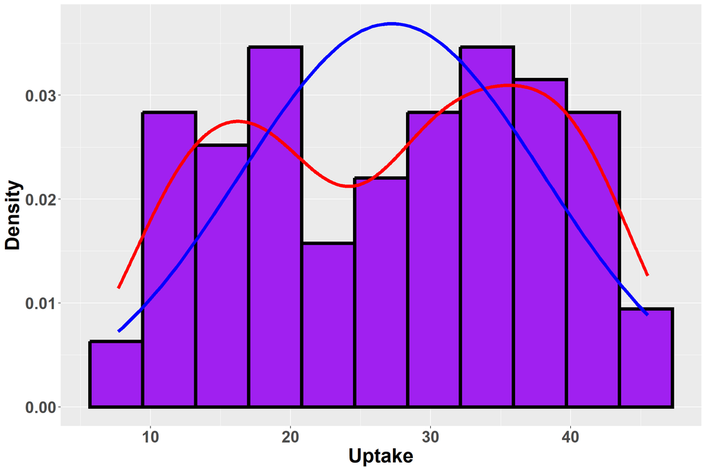

```r
n_bins <- max(round(sqrt(nrow(CO2))+2), 5)



ggplot(CO2, aes(uptake)) +
  geom_histogram(aes(y = after_stat(density)),bins= n_bins, fill="purple", col="black", linewidth = 2) +
  geom_density(col="red", lwd=2) +
  stat_function(fun=dnorm, args = list(mean = xbar, sd = s),
                col = "blue", lwd = 2) +
  theme(text=element_text(size=24, face = "bold"),axis.text=element_text(size=20)) +
  ylab("Density") +
  xlab("Uptake")
```

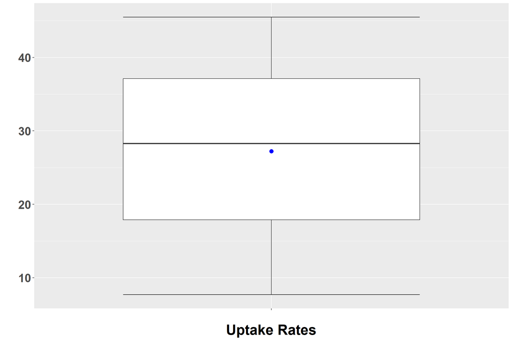

```r
ggplot(CO2, aes(x = "", y = uptake)) +
  stat_boxplot(geom="errorbar") +
  geom_boxplot(outlier.color = "red", outlier.shape = 8, outlier.size = 4) +
  theme(text=element_text(size=24, face = "bold"),axis.text=element_text(size=20)) +
  stat_summary(fun = mean, col = "blue", geom = "point", size = 3) +
  ylab("") +
  xlab("Uptake Rates")
```

Numerical Analysis

- **Central Tendencies:** The sample mean ($\bar{x} = 27.21$) and sample median ($\tilde{x} = 28.3$) suggest a potential slight negative skew.
- **Spread:** The sample standard deviation ($s = 10.81$) and interquartile range ($IQR = 19.225$) indicate a moderate level of variability in the data.

Graphical Analysis

- **Modified Boxplot:** The boxplot appears fairly symmetrical as the distances between quartiles are quite similar. The sample mean is less than the sample median, which suggests a possible negative skew. No visible explicit outliers are present.
- **Histogram:** The histogram shows a clear bi-modal pattern, supported by the added smooth kernel curve. This bi-modality suggests two separate distributions of uptake, which may be related to qualitative variables.

In R, functional programming simplifies iterating over data and applying operations with concise and declarative code. For example, tapply applies a function to subsets of a vector, grouped by a qualitative variable (see help(tapply) for details).

## Question 5:

Using the tapply function in R, we can easily compute statistics by groups. Compute the mean and standard deviation of the uptake as a function of the Type variable, i.e., run the following commands: tapply(CO2$uptake, CO2$Type, mean) and tapply(CO2$uptake, CO2$Type, sd) and save the output as variables. Report your output here.

```r
xbar <- tapply(CO2$uptake, CO2$Type, mean)
s <- tapply(CO2$uptake, CO2$Type, sd)
# Create a data frame for better formatting
stats_df <- data.frame(
  Type = names(xbar),
  Mean = round(xbar, 2),
  SD = round(s, 2)
)

# Print the data frame
print(stats_df, row.names = FALSE)
```

```
##         Type  Mean   SD
##       Quebec 33.54 9.67
##  Mississippi 20.88 7.82
```

Now, we are going to graphically visualize the distribution of the sample uptake rates as a function of Type. First, we will create a side-by-side boxplot.

## Question 6:

Use the ggplot2 package to plot uptake on the y-axis and Type on the x-axis, with each box representing one of the two Type categories (Quebec and Mississippi). Label the axes appropriately and ensure the title reflects the purpose of the graph. Describe any differences you observe between the distributional characteristics of uptake across the categories of Type.

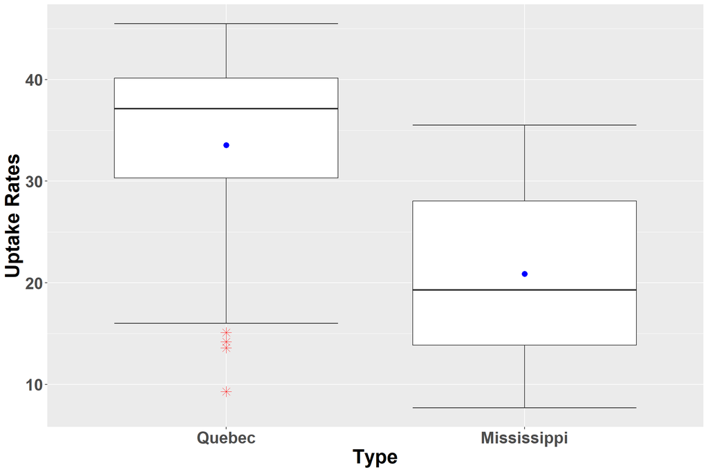

```r
ggplot(CO2, aes(x = Type, y = uptake)) +
  stat_boxplot(geom="errorbar") +
  geom_boxplot(outlier.color = "red", outlier.shape = 8, outlier.size = 4) +
  theme(text=element_text(size=24, face = "bold"),axis.text=element_text(size=20)) +
  stat_summary(fun = mean, col = "blue", geom = "point", size = 3) +
  ylab("Uptake Rates") +
  xlab("Type")
```

There are clear differences in the distribution of uptake rates between the two locations. Plants treated at the Mississippi facility tend to have much lower uptake rates than that of Quebec and the distribution has a slight positive skew for the Mississippi treated plants. The uptake rates for those treated in Quebec tend to have a much larger mean but with a strong negative skew, there are also a few explicit points on the low end and one of them might be considered ‘real’.

While a boxplot summarizes key statistics like medians and outliers, a histogram reveals the shape of the data, including skewness, multimodality, and distribution of values across its range.

## Question 7

Create a histogram of uptake as a function of Type using ggplot2. First, use tapply to calculate the mean and standard deviation of uptake for each Type. Then, use ifelse to compute a new column, normal.density, by applying the normal density formula conditionally, based on whether the Type is Quebec or Mississippi. Plot uptake on the x-axis and density on the y-axis, using facet_wrap to create separate panels for each Type. Overlay the histogram with a red kernel density curve and a blue normal density curve to compare distributions between Quebec and Mississippi.

Describe any differences you observe between the distributional characteristics of uptake across the categories of Type.

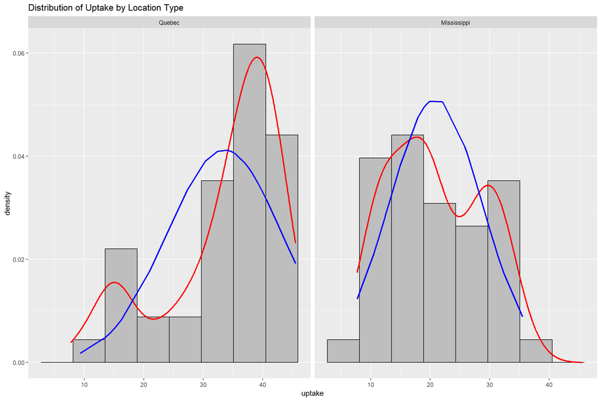

```r
xbar <- tapply(CO2$uptake, CO2$Type, mean)
s <- tapply(CO2$uptake, CO2$Type, sd)
n <- tapply(CO2$uptake, CO2$Type, length)
n_bins <- max(round(sqrt(max(n))+2), 5)

CO2$normal.density <- ifelse(CO2$Type == "Quebec",
                                dnorm(CO2$uptake, xbar["Quebec"], s["Quebec"]),
                                dnorm(CO2$uptake, xbar["Mississippi"], s["Mississippi"]))


ggplot(CO2, aes(x = uptake)) +
  geom_histogram(aes(y = after_stat(density)), bins = n_bins, fill = "grey", col = "black") +
  facet_grid(. ~ Type) +
  geom_density(col = "red", lwd = 1) +
  geom_line(aes(y = normal.density), col = "blue", lwd = 1) +
  labs(title = "Distribution of Uptake by Location Type")
```

There are clear differences in the distribution of uptake rates between the two locations. The negatively skewed pattern is obvious in the histogram for the uptake rates for the Quebec location but no noticeable outliers. In terms of the Mississippi location the distribution looks somewhat symmetric with some minor bi-modal behavior.

The relationship between uptake and conc (ambient CO2 concentration) is an important aspect of the dataset, as it reflects how plants respond to varying levels of CO2 in their environment. Unlike Type, which has only two categories, conc includes multiple distinct categories, representing different experimental conditions. To analyze this relationship, we will create visualizations to explore how uptake varies across these values of conc and discuss challenges and remedies when plotting data with multiple numerical categories.

## Question 8

Create a side-by-side boxplot to visualize the distribution of uptake as a function of conc using ggplot2. Plot uptake on the y-axis and conc on the x-axis. What do you observe about the boxplot? Why does this approach not work as intended? Hint: Consider how the conc variable is being treated in the plot.

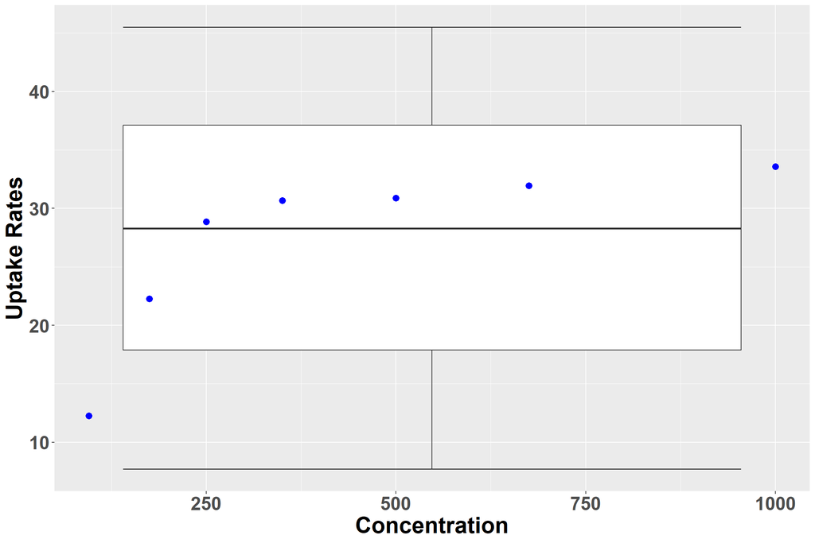

```r
ggplot(CO2, aes(x = conc, y = uptake)) +
  stat_boxplot(geom="errorbar") +
  geom_boxplot(outlier.color = "red", outlier.shape = 8, outlier.size = 4) +
  theme(text=element_text(size=24, face = "bold"),axis.text=element_text(size=20)) +
  stat_summary(fun = mean, col = "blue", geom = "point", size = 3) +
  ylab("Uptake Rates") +
  xlab("Concentration")
```

The concentration variable is being treated as numerical which is not the intention.

## Question 9

Remedy the issue observed by converting the conc variable into a factor: CO2$conc <- as.factor(CO2$conc). Recreate the side-by-side boxplot after applying this change. Describe any differences you observe between the distributional characteristics of uptake across the categories of conc.

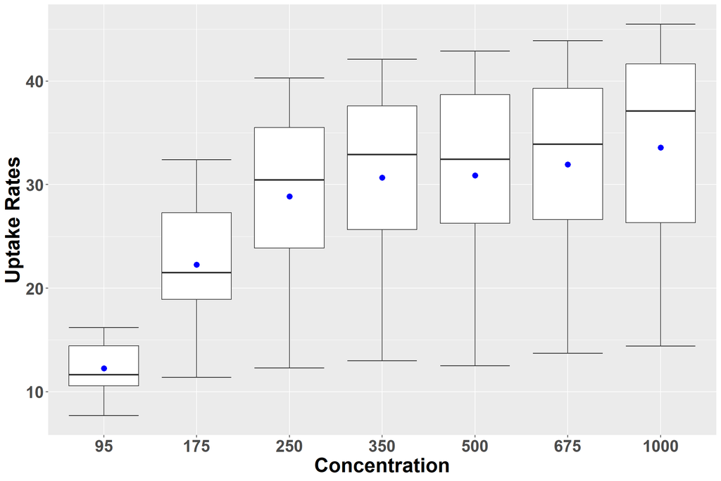

```r
CO2$conc <- as.factor(CO2$conc) # Important to convert the numerical values to be treated as a category

ggplot(CO2, aes(x = conc, y = uptake)) +
  stat_boxplot(geom="errorbar") +
  geom_boxplot(outlier.color = "red", outlier.shape = 8, outlier.size = 4) +
  theme(text=element_text(size=24, face = "bold"),axis.text=element_text(size=20)) +
  stat_summary(fun = mean, col = "blue", geom = "point", size = 3) +
  ylab("Uptake Rates") +
  xlab("Concentration")
```

There is a clear increase in the uptake rates as the amount of ambient carbon dioxide concentration increases. There is also a change in skewness from positive skew for concentration values less than 250 mL/L to negative skew for values greater than 175 mL/L. There are no noticeable explicit points in any of the boxplots.

First, use tapply to calculate the mean and standard deviation of uptake for each conc value. Next, write a function that computes the normal density for a given uptake and conc value using statistics (xbar, s).

Using the function you just created in conjunction with the mapply function, obtain the density values for the normal curve and store it in your data:  
CO2$normal.density <- mapply(your_function, CO2$uptake, CO2$conc).

## Question 10

Create a histogram of uptake as a function of conc using ggplot2. Plot uptake on the x-axis and density on the y-axis, using facet_wrap to create separate panels for each Type and add separate plotting rows: facet_wrap(~ conc, nrow = 2).

Overlay the histogram with a red kernel curve and a blue normal density curve to compare distributions across concentration levels. Describe any differences you observe between the distributional characteristics of uptake across the categories of conc.

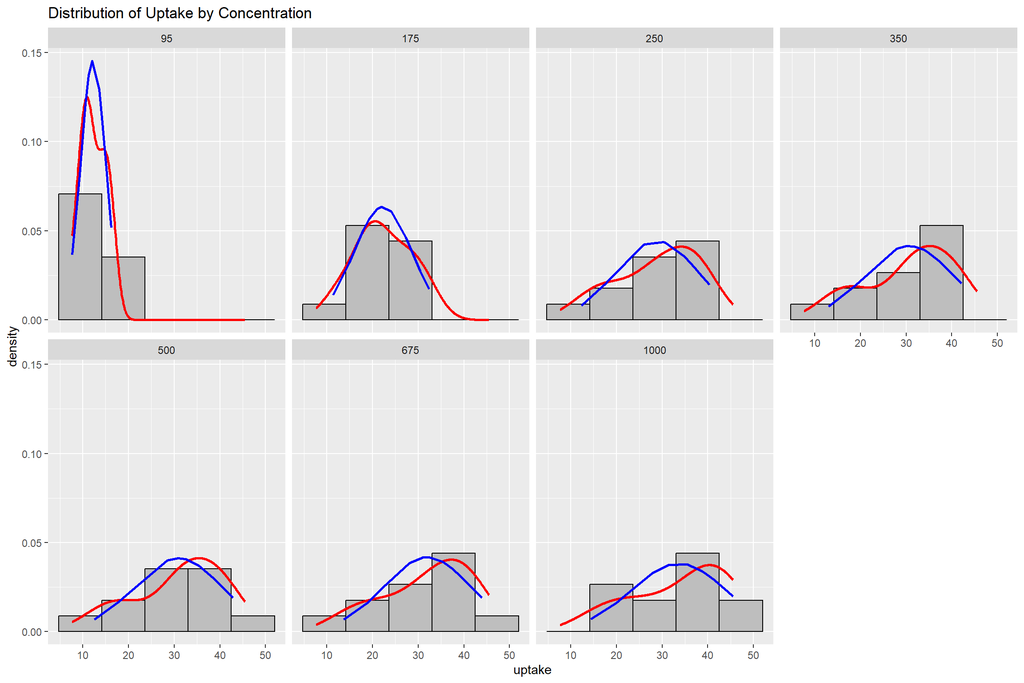

```r
xbar <- tapply(CO2$uptake, CO2$conc, mean)
s <- tapply(CO2$uptake, CO2$conc, sd)

n_bins <- round(sqrt(12)+2)

# Create function
calculate_density <- function(uptake, concentration) {
  dnorm(uptake, mean = xbar[concentration], sd = s[concentration])
}


CO2$normal.density <- mapply(calculate_density, CO2$uptake, CO2$conc)


ggplot(CO2, aes(x = uptake)) +
  geom_histogram(aes(y = after_stat(density)), bins = n_bins, fill = "grey", col = "black") +
  facet_wrap(~ conc, nrow = 2) +  # Arrange graphs in 2 rows
  geom_density(col = "red", lwd = 1) +
  geom_line(aes(y = normal.density), col = "blue", lwd = 1) +
  labs(title = "Distribution of Uptake by Concentration")
```

The observed positive skewness at low concentrations can be attributed to the restriction that CO₂ concentrations must be non-negative (≥ 0 mL/L). This constraint limits the lower tail of the distribution, resulting in a skewed pattern. At higher concentrations, the distribution appears more consistent and transitions to a slightly negative skew, with the mean uptake progressively increasing as the ambient CO₂ concentration rises. This behavior reflects the physiological response of plants to increasing carbon dioxide levels, where higher availability of CO₂ facilitates greater uptake within the experimental range.

### For Reference:

- **ifelse**
  - **Purpose**: Vectorized conditional function that evaluates a condition and returns one value if **TRUE** and another if **FALSE**.
  - **Usage**: ifelse(condition, value_if_true, value_if_false)
  - **Why Used**: Straightforward for binary conditions.
  - **Alternative**: The **dplyr** library provides more flexibility for multiple conditions using the case_when function.
- **tapply**
  - **Purpose**: Applies a function (e.g., **mean**, **sd**) to subsets of a vector grouped by a categorical variable.
  - **Usage**: tapply(vector, grouping_variable, function)
  - **Why Used**: Simple and efficient for grouped calculations with categorical variables.
  - **Alternative**: In the **dplyr** library, the same task can be achieved using **group_by** and **summarise**.
- **mapply**
  - **Purpose**: Applies a function to multiple arguments simultaneously.
  - **Usage**: mapply(function, arg1, arg2, …)
  - **Why Used**: Flexible for dynamic, row-wise calculations involving multiple variables.
  - **Alternative**: In libraries like **dplyr** or **purrr**, similar results can be achieved with **mutate** or **map2**.